# CNN Model for Disease Classification

The following describes my workflow and rationale for design of a supervised image classification CNN model for pneumonia diagnosis. The model takes in 2D BW images of chest x-rays and outputs as "pneumonia" or "non-pneumonia" label. I used tensorflow for python v3.10.(Dataset available on Kaggle and from https://ieeexplore.ieee.org/abstract/document/8741582)

## Workflow:

**Import and view data-** I compressed images to speed up training and import time. Could possibly go back to this step and use non-compressed images to see how it affects accuracy.

**Clean and Organize data-** Some of the images were RGB instead of BW so I wrote a program to take care of this. After cleaning I made sure to visualize these images to make sure they looked right. I also put all of the images into an array suitable for the CNN.

**Design the Network:** The model was built in a similar way to what was published in the IEEE link, with blocks of convolution. However, I started with a less is more approach and played around with layer number and size, adding and tweaking things based on intuition.

**Troubleshooting:** Overfitting was a huge problem at first, so I added a few dropout steps. Adding the larger dense layer in between drop out steps really helped performance. I also had an issue of step sizes being too large so I scheduled the learning rate with exponential decay and it helped with fluidity and convergence.

**Model Performance and Validation:** I assessed accuracy and precision, and looked at confusion matrices of test and validation sets. If this model were to be used in diagnostics, very few pneumonia diagnoses would be missed. For the test set, 91.5% of pneumonia cases were labeled as such. However, there were more false positives than I would have liked, with 23% of negative cases being labeled positive. I believe this model is comparable to the one published with this dataset.

## Environment Set Up

```python
# Import packages
import sys
import numpy as np
import pandas as pd
import tensorflow as tf
import sklearn
from skimage.transform import resize
from skimage import color
from tensorflow import keras
import matplotlib.pyplot as plt
import matplotlib.image as mpimg

import os
imSize=224 #image size that I'll use in the NN
print(tf.version)
```

```
<module 'tensorflow._api.v2.version' from 'C:\\Users\\S421596\\Anaconda3\\envs\\python3_10\\lib\\site-packages\\tensorflow\\_api\\v2\\version\\__init__.py'>
```

## Data Loading and Processing

```python
# TRAINING SET
#define the locations of the files
nTrainDir='C:/Users/S421596/Documents/MLpractice/chest_xray/train/NORMAL/'
trainListNorm=os.listdir(nTrainDir)
pTrainDir='C:/Users/S421596/Documents/MLpractice/chest_xray/train/PNEUMONIA/'
trainListP=os.listdir(pTrainDir)
imSize=224

#write a function to make sure every image is grayscale. A few images were RGB
def rgb2gray(rgb):
    return np.dot(rgb[...,:3], [0.2989, 0.5870, 0.1140])

#write a function to rescale images to decrease computational demand
def scale_resize_image(image):
    #image=rgb2gray(image)
    image = image/255
    image = resize(image, (imSize,imSize)) # Resizing the image to 224x224 dimension
    return (image)

os.chdir(nTrainDir)
#trainX=np.zeros((imSize,imSize,len(trainListNorm)+len(trainListP)), dtype=float) #instead of object
trainX=np.zeros((len(trainListNorm)+len(trainListP),imSize,imSize), dtype=float) #instead of object
#trainY=np.array(['Normal']*(trainX.shape[2]), dtype=object)
trainY=np.array(['Normal']*(len(trainX)), dtype=object)
trainY[len(trainListNorm):]="Pneumonia"

#trainY1=np.zeros((trainX.shape[2],2)) #change back to just [0] and silence next two lines
trainY1=np.zeros((len(trainX),2)) #change back to just [0] and silence next two lines
trainY1[len(trainListNorm):,1]=1
trainY1[0:len(trainListNorm),0]=1 #first column is "not pneumonia


for im in range(0,len(trainListNorm)):
    image=mpimg.imread(trainListNorm[im])
    if len(image.shape)>2:
        #print(im)
        image = image.convert('L') # convert the image to *greyscale* because one of them was color :(
        image = np.array(image)

    #trainX[:,:,im]=scale_resize_image(image) #original that works
    trainX[im]=scale_resize_image(image) #original that works

os.chdir(pTrainDir)
#trainY2=np.array(['Pneumonia']*(len(trainX2)),dtype=object)

#for im in range(len(trainListP),trainX.shape[2]):
for im in range(len(trainListP),len(trainX)):
    image=mpimg.imread(trainListP[im-len(trainListP)])
    if len(image.shape)>2:
        #print(im)
        image = color.rgb2gray(image) # convert the image to *greyscale* because one of them was color :(
        image = np.array(image)

    #trainX[:,:,im]=scale_resize_image(image)
    trainX[im]=scale_resize_image(image)

#print(trainX1[0].max())
print(trainX.shape,trainY1.shape)
```

```
(5216, 224, 224) (5216, 2)
```

```python
# TEST SET
#now make the test  sets in the same way
nTestDir='C:/Users/S421596/Documents/MLpractice/chest_xray/test/NORMAL/'
pTestDir='C:/Users/S421596/Documents/MLpractice/chest_xray/test/PNEUMONIA/'
listNorm=os.listdir(nTestDir)
listP=os.listdir(pTestDir)
os.chdir(nTestDir)

#testX=np.zeros((imSize,imSize,len(listNorm)+len(listP)), dtype=float) #instead of object
testX=np.zeros((len(listNorm)+len(listP),imSize,imSize), dtype=float) #instead of object
#testY=np.array(['Normal']*(testX.shape[2]),dtype=object)
testY=np.array(['Normal']*(len(testX)),dtype=object)
testY[len(listNorm):]="Pneumonia"

#testY1=np.zeros((testX.shape[2],2)) #change back to just [0] and silence next two lines
testY1=np.zeros((len(testX),2)) #change back to just [0] and silence next two lines
testY1[len(listNorm):,1]=1
testY1[0:len(listNorm),0]=1 #first column is "not pneumonia


for im in range(0,len(listNorm)):
    image=mpimg.imread(listNorm[im])
    if len(image.shape)>2:
        #print(im)
        image = color.rgb2gray(image) # convert the image to *greyscale* because one of them was color :(
        image = np.array(image)

    #testX[:,:,im]=scale_resize_image(image)
    testX[im]=scale_resize_image(image)

os.chdir(pTestDir)
#for im in range(len(listNorm),testX.shape[2]):
for im in range(len(listNorm),len(testX)):
    image=mpimg.imread(listP[im-len(listNorm)])
    if len(image.shape)>2:
        #print(im)
        image = color.rgb2gray(image) # convert the image to *greyscale* because one of them was color :(
        image = np.array(image)
    #testX[:,:,im]=scale_resize_image(image)
    testX[im]=scale_resize_image(image)

print(testX.shape,testY1.shape)
print(type(testY1[0]))
```

```
(624, 224, 224) (624, 2)
<class 'numpy.ndarray'>
```

```python
# VALIDATION SET
nValDir='C:/Users/S421596/Documents/MLpractice/chest_xray/val/NORMAL/'
pValDir='C:/Users/S421596/Documents/MLpractice/chest_xray/val/PNEUMONIA/'
listNorm=os.listdir(nValDir)
listP=os.listdir(pValDir)
os.chdir(nValDir)

#valX=np.zeros((imSize,imSize,len(listNorm)+len(listP)), dtype=float) #instead of object
valX=np.zeros((len(listNorm)+len(listP),imSize,imSize), dtype=float) #instead of object
#valY=np.array(['Normal']*(valX.shape[2]),dtype=object)
valY=np.array(['Normal']*(len(valX)),dtype=object)
valY[len(listNorm):]="Pneumonia"

#valY1=np.zeros((valX.shape[2],2)) #change back to just [0] and silence next two lines
valY1=np.zeros((len(valX),2)) #change back to just [0] and silence next two lines
valY1[len(listNorm):,1]=1 #end of "normal" pictures +1 to end of array in 2nd column will be 1 for "pneumonia cases"
valY1[0:len(listNorm),0]=1 #first column is "not pneumonia

for im in range(0,len(listNorm)):
    image=mpimg.imread(listNorm[im])
    if len(image.shape)>2:
        #print(im)
        image = color.rgb2gray(image) # convert the image to *greyscale* because one of them was color :(
        image = np.array(image)
    #valX[:,:,im]=scale_resize_image(image)
    valX[im]=scale_resize_image(image)

os.chdir(pValDir)
#for im in range(len(listNorm),valX.shape[2]):
for im in range(len(listNorm),len(valX)):
    image=mpimg.imread(listP[im-len(listNorm)])
    if len(image.shape)>2:
        #print(im)
        image = color.rgb2gray(image) # convert the image to *greyscale* because one of them was color :(
        image = np.array(image)
    #valX[:,:,im]=scale_resize_image(image)
    valX[im]=scale_resize_image(image)

print(valX.shape,valY1.shape)
os.chdir('C:/Users/S421596/Documents/MLpractice/chest_xray/models')
```

```
(16, 224, 224) (16, 2)
```

## Plot Some of the Images

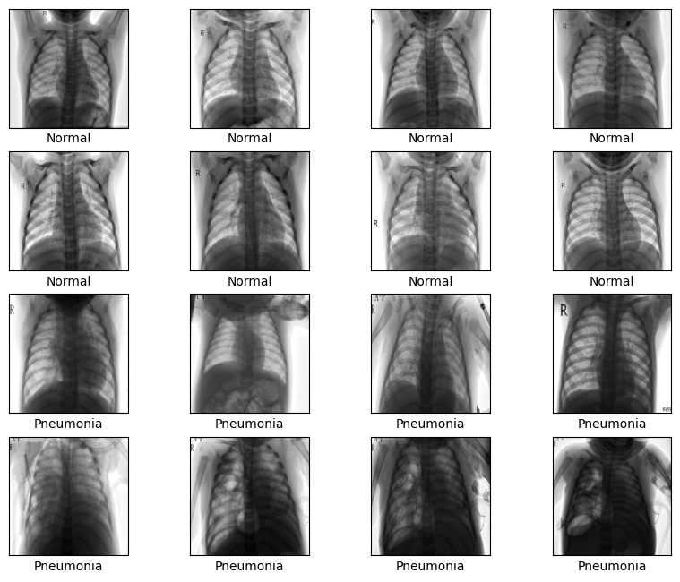

```python
#view the data (test set). The images still look pretty clear so the model should be able to detect differences
plt.figure(figsize=(10,10))
for i in range(16):
    if i<=7:
        plt.subplot(5,4,i+1)
        plt.xticks([])
        plt.yticks([])
        plt.grid(False)
        #plt.imshow(trainX[:,:,i], cmap=plt.cm.binary)
        plt.imshow(trainX[i,:,:], cmap=plt.cm.binary)
        plt.xlabel(trainY[i])
        #print(trainX[i].shape)
    else:
        plt.subplot(5,4,i+1)
        plt.xticks([])
        plt.yticks([])
        plt.grid(False)
        #plt.imshow(trainX[:,:,-1*i+7], cmap=plt.cm.binary)
        plt.imshow(trainX[-1*i+7,:,:], cmap=plt.cm.binary)
        plt.xlabel(trainY[-1*i+7])
        #print(trainX[-1*i+7].shape)
plt.show()
```

## Plot the "Altered" Images

(the ones that were changed from RGB to BW)

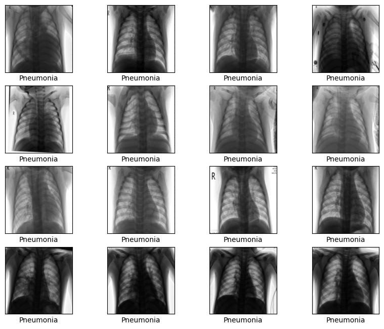

```python
# now print some of the images you converted to BW.. look good! Possibly a little dark

#view the data (test set)
plt.figure(figsize=(10,10))
imID=[3909,3910,3911,3940,3941,3942,4914,4915,4916,5030,5031,5032,5160,5161,5162,5163]
for i in range(16):
        plt.subplot(5,4,i+1)
        plt.xticks([])
        plt.yticks([])
        plt.grid(False)
        #plt.imshow(trainX[:,:,imID[i]], cmap=plt.cm.binary)
        plt.imshow(trainX[imID[i],:,:], cmap=plt.cm.binary)
        plt.xlabel(trainY[imID[i]])
        #print(trainX[i].shape)
plt.show()
```

## Build the Model

```python
#BEST ~91/83, with learning rate .00001, 15, 80 epochs, batch size 64. Converged at 93/85 (best test accuracy=86)
model = keras.models.Sequential([
keras.layers.Conv2D(3, 3, activation='relu',input_shape = [imSize,imSize,1]), #originally 3x3 kernel. 5x3 had 88% for LR .0001, 10?
keras.layers.Conv2D(5, 3, activation='relu',input_shape = [imSize,imSize,1]), #originally 3x3 kernel. 5x3 had 88% for LR .0001, 10?
keras.layers.Conv2D(5, 3, activation='relu',input_shape = [imSize,imSize,1]), #what happens if i duplicate?
tf.keras.layers.Dropout(0.4),
keras.layers.Flatten(),
keras.layers.Dense(90, activation = 'relu' ), #originally 128, 256 similar at ~85 for 3x3, 256 bad for 5x3
tf.keras.layers.Dropout(0.4),
keras.layers.Dense(32, activation = 'relu' ), #best 32
keras.layers.Dense(16, activation = 'relu' ), #best 32
keras.layers.Dense(16, activation = 'relu' ), #originally 16
keras.layers.Dense(2, activation = 'softmax' )])
model.summary()
```

```
Model: "sequential_47"
_________________________________________________________________
 Layer (type)                Output Shape              Param #
=================================================================
 conv2d_94 (Conv2D)          (None, 222, 222, 3)       30

 conv2d_95 (Conv2D)          (None, 220, 220, 5)       140

 conv2d_96 (Conv2D)          (None, 218, 218, 5)       230

 dropout_94 (Dropout)        (None, 218, 218, 5)       0

 flatten_47 (Flatten)        (None, 237620)            0

 dense_244 (Dense)           (None, 90)                21385890

 dropout_95 (Dropout)        (None, 90)                0

 dense_245 (Dense)           (None, 32)                2912

 dense_246 (Dense)           (None, 16)                528

 dense_247 (Dense)           (None, 16)                272

 dense_248 (Dense)           (None, 2)                 34

=================================================================
Total params: 21,390,036
Trainable params: 21,390,036
Non-trainable params: 0
_________________________________________________________________
```

## Compile the Model

```python
#compile the network

model.compile(loss = 'binary_crossentropy', #try SparseCategoricalCrossentropy was binary_crossentropy
    optimizer = 'adam',
    metrics = ['accuracy',tf.keras.metrics.Precision(name='precision')]) #

#set up exponential decay to schedule decreasing step sizes so that the model doesn't diverge
def exponential_decay(lr0, s):
    def exponential_decay_fn(epoch):
        return lr0 * 0.1 **(epoch / s)
    return exponential_decay_fn

exponential_decay_fn = exponential_decay(0.00001, 15) #first number is the initial learning rate, second number is the rate at which the learning rate decreases. Lower number = faster decrease
```

## Fit the Model

```python
#This took around 30 minutes to train
checkpoint_cb = tf.keras.callbacks.ModelCheckpoint("xray_model.h5",save_best_only=True)
early_stopping_cb = tf.keras.callbacks.EarlyStopping(monitor="val_accuracy",
                                                     patience=20, #the number of epochs that elapse without improvement
                                                     restore_best_weights=True)# plot history
lr_scheduler = tf.keras.callbacks.LearningRateScheduler(exponential_decay_fn)

#history = model.fit(trainX,y_train,epochs = 40,validation_data = (testX, y_test))
history = model.fit(trainX, trainY1,
                    epochs = 80,
                    validation_data = (testX, testY1),
                    batch_size=64, #added this at 64 because it kept getting stuck at .7429. 20 epochs finished around 80/100
                    callbacks=[lr_scheduler,early_stopping_cb,checkpoint_cb])
```

## Assess Performance

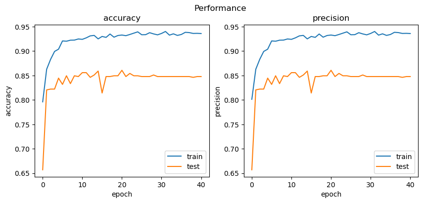

```python
plt.rcParams["figure.figsize"] = (10,4)
fig, (ax1, ax2) = plt.subplots(1, 2)
fig.suptitle('Performance')

ax1.plot(history.history['accuracy'])
ax1.plot(history.history['val_accuracy'])
ax1.set(title='accuracy')
ax1.set(ylabel='accuracy')
ax1.set(xlabel='epoch')
ax1.legend(['train', 'test'], loc='lower right')
ax1.figsize=[20,20]
#ax1.show()

ax2.plot(history.history['precision'])
ax2.plot(history.history['val_precision'])
ax2.set(title='precision')
ax2.set(ylabel='precision')
ax2.set(xlabel='epoch')
ax2.legend(['train', 'test'], loc='lower right')
plt.show()
```

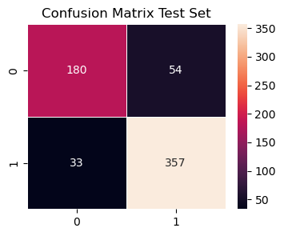

```python
#Now make and visualize confusion matrix for model
import seaborn as sns
from sklearn import metrics

#now evaluate the model
predictions = model.predict(testX)
predictions
y_pred=predictions.round(decimals=0)
matrix = sklearn.metrics.confusion_matrix(testY1[:,1]==1,y_pred[:,1]==1)
plt.rcParams["figure.figsize"] = (4,3)
ax = sns.heatmap(matrix, linewidth=0.5,annot=True, fmt='g')
ax.set(title='Confusion Matrix Test Set')
plt.show()

# Best model: true positives = 91.5% accuracy, true negatives = 77% accuracy
```

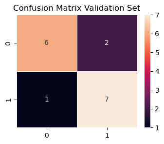

```python
# Now predict diagnosis for validation set and show confusion matrix
predictions = model.predict(valX)
predictions
y_pred=predictions.round(decimals=0)
matrix = sklearn.metrics.confusion_matrix(valY1[:,1]==1,y_pred[:,1]==1)
#print(matrix)
plt.rcParams["figure.figsize"] = (4,3)
ax = sns.heatmap(matrix, linewidth=0.5,annot=True, fmt='g')
ax.set(title='Confusion Matrix Validation Set')
plt.show()

# true positives = 87% accuracy, true negatives = 75% accuracy. Not a very big validation set. try with different size sets?
```

# Final thoughts and Future Directions

## Possible Areas of Improvement

**Contrast:** The contrast and white balance on the images seem to be quite variable. If I can normalize this somehow, it may improve model performance.

**Segmentation:** Radiological pneumonia diagnosis is made by noticing a "cloudiness" in the lungs, which are located in the center of these images. Therefore, the model likely "pays attention" to this location the most. Could segmentation allow for increased focus on this area and improvement in performance?

**Recurrant NN?:** Could I increase accuracy with recurrant layers?

**Low Sample Size:** This may be the best this particular model can do with such a low sample size. Increasing size of training dataset may improve performance